# 2IS50 – Software Development for Engineers – 2022-2023

### Automated Testing

With *one* click

- Execute each test case
  - Call function with selected arguments
  - Capture result
  - Check result
    - Either: compare *directly* against *expected result*
    - Or: check *indirectly* for a *property*
- Report on all test outcomes

### `doctest` examples in docstring

- You can put **usage examples** in a docstring
- You can do it in such a format that these examples are **automatically executable and checkable**

Format of **doctest** examples/test cases in docstring:

```
>>> expression with function call
expected result
...
...
>>> expression with function call
expected result
```

```python
def roll_dice(n: int) -> List[int]:
    """Roll n regular dice and return outcomes in a list.

    Assumption: n >= 0.

    Examples and test cases:

    >>> roll_dice(0)  # boundary case
    []
    >>> len(roll_dice(2))  # test length
    2
    >>> all(roll in range(1, 6+1) for roll in roll_dice(10))  # test values
    True
    """
    return [random.randint(1, 12) for _ in range(n)]
```

Note that:

- Boundary test case is a *direct* test
- Other test cases are *indirect*
  - They check for a desirable property, by applying a function to the result, and inspecting that

### How to run `doctest` examples in Jupyter notebook

- `import doctest`
- `doctest.run_docstring_examples(func, globals(), verbose=True, name='...')`
  - Runs all test cases of `func`, reporting *all details*
- `doctest.run_docstring_examples(func, globals(), verbose=False)`
  - Runs all test cases, *only reporting failures*

```python
import doctest
```

```python
doctest.run_docstring_examples(roll_dice, globals(), verbose=True, name='roll_dice')
```

```
Finding tests in roll_dice
Trying:
    roll_dice(0)  # boundary case
Expecting:
    []
ok
Trying:
    len(roll_dice(2))  # test length
Expecting:
    2
ok
Trying:
    all(roll in range(1, 6+1) for roll in roll_dice(10))  # test values
Expecting:
    True
File "__main__", line 12, in roll_dice
Failed example:
    all(roll in range(1, 6+1) for roll in roll_dice(10))  # test values
Expected:
    True
Got:
    False
```

Did you spot the defect in the code for `roll_dice`?

You can also run the test cases more quietly, only showing test cases that failed:

```python
doctest.run_docstring_examples(roll_dice, globals(), verbose=False, name='roll_dice')
```

```
File "__main__", line 12, in roll_dice
Failed example:
    all(roll in range(1, 6+1) for roll in roll_dice(10))  # test values
Expected:
    True
Got:
    False
```

Two more examples of tests in docstring:

```python
OPTIONS = {0: "Rock", 1: "Paper", 2: "Scissors"}
RPS = ''.join(name[0].lower() for name in OPTIONS.values())

def rps_choice(letter: str) -> int:
    """Return choice integer corresponding to given letter.

    The letter is first converted to lower case.

    Assumptions:
    * len(letter) == 1
    * letter.lower() in RPS

    >>> rps_choice('r')
    0
    >>> rps_choice('P')
    1
    >>> rps_choice('s')
    2
    >>> rps_choice('X')
    Traceback (most recent call last):
        ...
    AssertionError: letter.lower() must be in RPS
    """
    assert letter.lower() in RPS, "letter.lower() must be in RPS"

    return RPS.index(letter.lower())
```

```python
doctest.run_docstring_examples(rps_choice, globals(), verbose=False, name='rps_choice')
```

Note that we also tested for **expected exceptions**.

```python
def beats(choice_1: int, choice_2: int) -> bool:
    """Return whether choice_1 beats choice_2.

    Assumption: choice_1 in OPTIONS and choice_2 in OPTIONS

    :param choice_1: choice of first player
    :param choice_2: choice of second player
    :return: whether choice_1 beats choice_2

    :examples:

    >>> beats(0, 0)
    False
    >>> beats(0, 1)
    False
    >>> beats(1, 0)
    True
    >>> beats(0, 2)
    True
    """
    return choice_1 > choice_2  # (choice_1 - choice_2) % 3 == 1
```

```python
doctest.run_docstring_examples(beats, globals(), verbose=False, name='beats')
```

```
File "__main__", line 18, in beats
Failed example:
    beats(0, 2)
Expected:
    True
Got:
    False
```

So, there is a defect ... somewhere

**Exhaustive testing** usually not possible/desirable.

Separate test cases (not in docstring; *note the indentation*):

```python
beats_test = """
    >>> beats(2, 2)  # was missed above!
    False
"""
```

```python
doctest.run_docstring_examples(beats_test, globals(), verbose=True, name='beats_test')
```

```
Finding tests in beats_test
Trying:
    beats(2, 2)  # was missed above!
Expecting:
    False
ok
```

Test calls must produce *predictable* output:

- Sets and dictionaries do *not* print in a specific reproducible order
- Instead:
  - turn them into a sorted list, or
  - compare them to expected result

```python
set_test = """
    >>> set("asdf")
    {'a', 's', 'd', 'f'}
"""
```

```python
doctest.run_docstring_examples(set_test, globals(), verbose=True, name='set_test')
```

```
Finding tests in set_test
Trying:
    set("asdf")
Expecting:
    {'a', 's', 'd', 'f'}
Line 2, in set_test
Failed example:
    set("asdf")
Expected:
    {'a', 's', 'd', 'f'}
Got:
    {'s', 'a', 'd', 'f'}
```

```python
set_test = """
    >>> set("asdf") == {'a', 's', 'd', 'f'}
    True
"""
```

```python
doctest.run_docstring_examples(set_test, globals(), verbose=True, name='set_test')
```

```
Finding tests in set_test
Trying:
    set("asdf") == {'a', 's', 'd', 'f'}
Expecting:
    True
ok
```

Disadvantage: you won't see the actual set value in case of a failure

```python
set_test = """
    >>> sorted(set("asdf"))
    ['a', 'd', 'f', 's']
"""
```

```python
doctest.run_docstring_examples(set_test, globals(), verbose=True, name='set_test')
```

```
Finding tests in set_test
Trying:
    sorted(set("asdf"))
Expecting:
    ['a', 'd', 'f', 's']
ok
```

### How to run `doctest` examples for all functions

- `doctest.testmod(verbose=True)` runs all test cases, reporting details
- `doctest.testmod(verbose=False)` runs all test cases, showing a summary

```python
doctest.testmod(verbose=True)  # with details
```

```
Trying:
    beats(0, 0)
Expecting:
    False
ok
Trying:
    beats(0, 1)
Expecting:
    False
ok
Trying:
    beats(1, 0)
Expecting:
    True
ok
Trying:
    beats(0, 2)
Expecting:
    True
File "__main__", line 18, in __main__.beats
Failed example:
    beats(0, 2)
Expected:
    True
Got:
    False
Trying:
    roll_dice(0)  # boundary case
Expecting:
    []
ok
Trying:
    len(roll_dice(2))  # test length
Expecting:
    2
ok
Trying:
    all(roll in range(1, 6+1) for roll in roll_dice(10))  # test values
Expecting:
    True
```

[output cut: 25 more lines]

```
    Traceback (most recent call last):
        ...
    AssertionError: letter.lower() must be in RPS
ok
2 items had no tests:
    __main__
    __main__.reverse_list
1 items passed all tests:
   4 tests in __main__.rps_choice
2 items had failures:
   1 of   4 in __main__.beats
   1 of   3 in __main__.roll_dice
11 tests in 5 items.
9 passed and 2 failed.
***Test Failed*** 2 failures.
```

```
TestResults(failed=2, attempted=11)
```

```python
doctest.testmod(verbose=False)  # without details
```

```
File "__main__", line 18, in __main__.beats
Failed example:
    beats(0, 2)
Expected:
    True
Got:
    False
File "__main__", line 12, in __main__.roll_dice
Failed example:
    all(roll in range(1, 6+1) for roll in roll_dice(10))  # test values
Expected:
    True
Got:
    False
2 items had failures:
   1 of   4 in __main__.beats
   1 of   3 in __main__.roll_dice
***Test Failed*** 2 failures.
```

```
TestResults(failed=2, attempted=11)
```

### PyCharm & `doctest`

PyCharm has built-in facilities

- to find and execute `doctest` examples
- to report details about failures

See Homework Assignment 0.

### `pytest` test framework

Pytest is a complete **testing framework**

- It uses `assert` statement to check expectations
- Each test case is written as a function
  - Name must start with `test_...`
- Framework has extensive failure reporting
  - Shows details of differences

### Testing advice for `pytest`

- Each `test_...` function should contain only *one* test case
  - Do not combine multiple test cases
  - Reason: `test_...` function stops at first failure
- Keep `test_...` functions *independent* of each other
  - Reason: `test_...` functions are executed *in arbitrary order*

## Version Control with Git

- Git can be used on command line (via CLI)
  - or via separate GUI
- We will use Git through PyCharm
- Usage scenarios:
  - Single user
  - Multiple users

### Git concepts

- Remote & local *repository* (*repo* in jargon)
  - Repo has: complete history, as sequence of *commits*
  - Each commit has: *change set* & *commit message*
  - Each commit is identified by a *commit hash*
- Working copy, staging area
- Commands
  - Clone (PyCharm: VCS > Get from Version Control...)
  - Add, commit, push
  - Pull (only for multi-user)

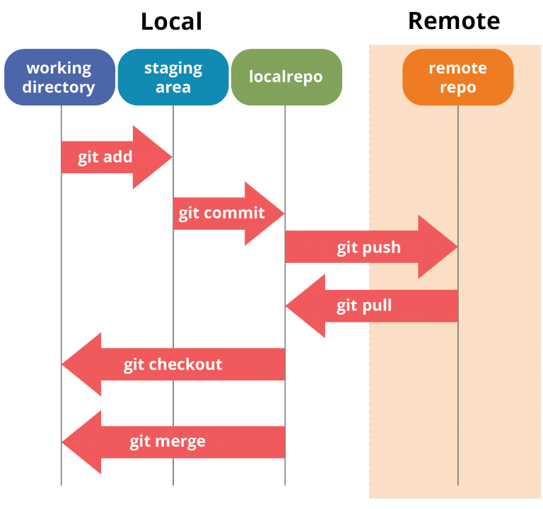

Source: https://www.edureka.co/blog/git-tutorial/

PyCharm manages the staging area

- **Add file to VCS** in PyCharm $\ne$ add to staging area

### PyCharm: select files to commit in the *Git tool window*

[figure not shown]

See: https://www.jetbrains.com/help/pycharm/commit-and-push-changes.html?section=Windows%20or%20Linux#

### PyCharm: *Partial* commits

Select changes to commit per *chunk*

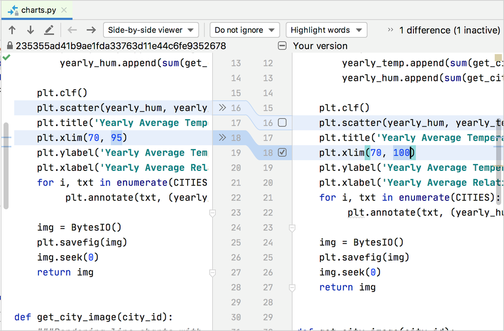

### PyCharm: Undo last commit (if not yet pushed)

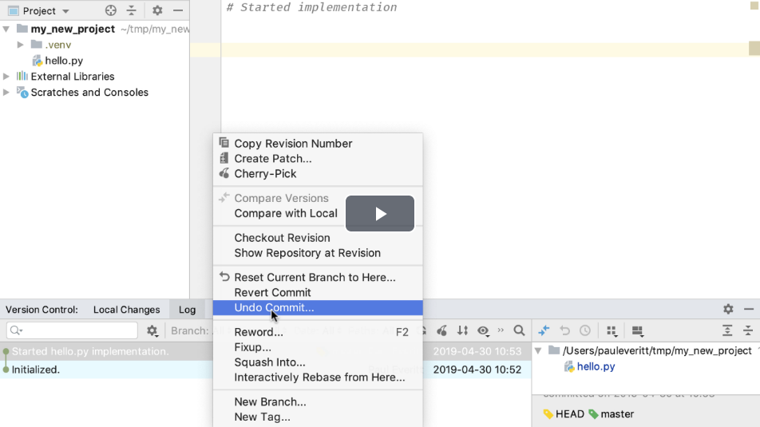

Video: https://www.jetbrains.com/pycharm/guide/tips/undo-last-commit/

### Trunk-Based Development (TBD)

There are many Git *workflows*.

We will use *Trunk-Based Development,* without creating new branches.

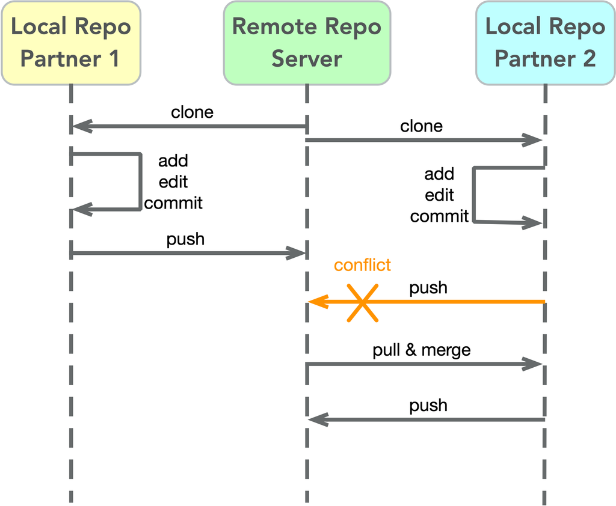

Source: Tom Verhoeff

### If push fails

- Reason: Your local repo is out-of-sync with remote repo
- Someone else already pushed new changes that you miss

How to handle:

- **First pull** and resolve merge conflicts
- **Then push** again (fingers crossed)

Advice: Communicate with your co-developers, to avoid this situation

### PyCharm: Resolve merge conflicts

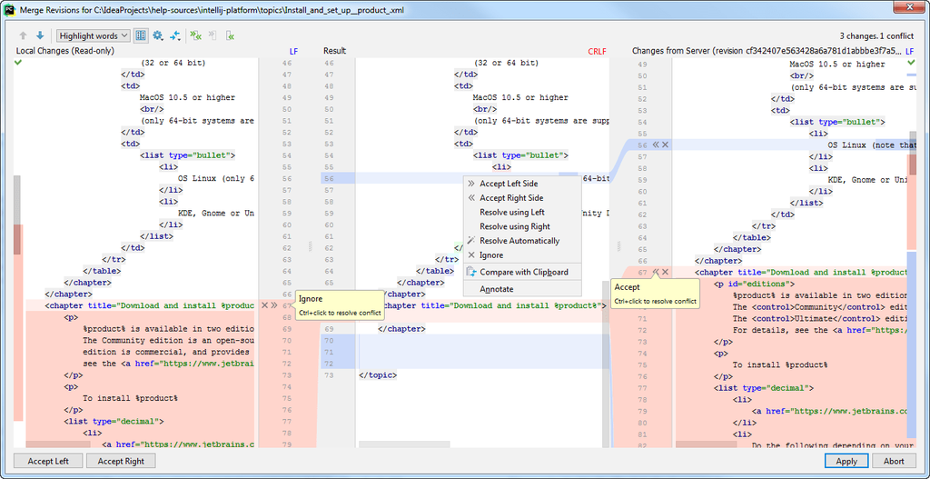

See: https://www.jetbrains.com/help/pycharm/resolving-conflicts.html

## (End of Notebook)

© 2019-2023 - **TU/e** - Eindhoven University of Technology - Tom Verhoeff